# Guided Project: Answering Business Questions with RSQLite

First, the setup. Connect to Chinook database:

```r
library(RSQLite)
library(DBI)
db <- "chinook.db"
conn <- dbConnect(SQLite(), db)
tables <- dbListTables(conn)
```

Make helper functions and display a list of tables contained in the database:

```r
run_query <- function(query) {
  conn <- dbConnect(SQLite(), db)
  result <- dbGetQuery(conn, query)
 # dbDisconnect(conn)
  return(result)
}

show_tables <- function(){
   query <- "SELECT name, type FROM sqlite_master WHERE type IN ('table', 'view')"
  return(run_query(query))
}

show_tables()
```

| name | type |
| --- | --- |
| album | table |
| artist | table |
| customer | table |
| employee | table |
| genre | table |
| invoice | table |
| invoice_line | table |
| media_type | table |
| playlist | table |
| playlist_track | table |

[output cut: 4 more lines]

Here is the relational schema for this database:

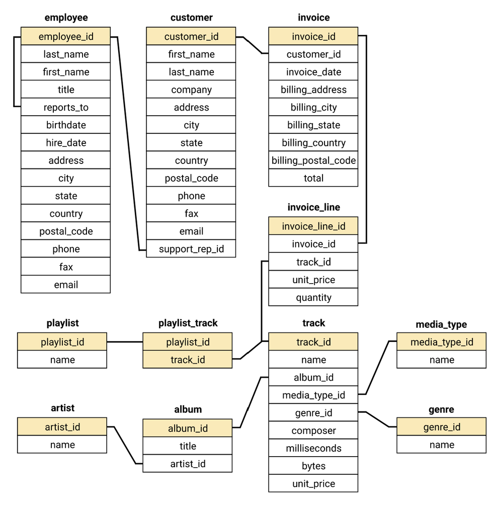

Next, set theme for plots:

```r
library(ggplot2)
my_theme <- theme(axis.line.x.bottom = element_line(size = 0.25),
                  axis.line.y.left = element_line(size = 0.25),
                  panel.background = element_rect(fill = "white"),
                  panel.grid = element_blank())

theme_set(my_theme)
```

# The situation:

The Chinook record store has just signed a deal with a new record label, and we are in charge of choosing the first three albums to be added to the store. There are four albums to choose from, and all four are by artists who don’t have any tracks in the store right now. Here is the list of artist names and the genre of music they produce:

| Artist name | Genre |
| --- | --- |
| Regal | Hip-Hop |
| Red Tone | Punk |
| Meteor and the Girls | Pop |
| Slim Jim Bites | Blues |

The record label specializes in artists from the US, so they have given Chinook some money to advertise the new albums in the USA. In order to choose which albums to buy, we need to identify the best-selling genres in the USA.

# Which new albums should be added?

## 1. Which genres sell the most in the USA?

Solution with SQL query as string:

```r
to_purchase <- '
WITH usa_sales AS
   (
    SELECT il.*
    FROM invoice_line AS il
    INNER JOIN invoice AS i ON il.invoice_id = i.invoice_id
    INNER JOIN customer AS c ON i.customer_id = c.customer_id
    WHERE c.country = "USA"
   )
SELECT
    g.name AS genre,
    count(us.invoice_line_id) AS tracks_sold,
    cast(count(us.invoice_line_id) AS FLOAT)/(
        SELECT COUNT(*) from usa_sales
    ) AS percentage_tracks_sold
FROM usa_sales AS us
INNER JOIN track AS t ON t.track_id = us.track_id
INNER JOIN genre g ON g.genre_id = t.genre_id
GROUP BY genre
ORDER BY percentage_tracks_sold DESC
LIMIT 10;
'
run_query(to_purchase)
```

| genre | tracks_sold | percentage_tracks_sold |
| --- | --- | --- |
| Rock | 561 | 0.53377735 |
| Alternative & Punk | 130 | 0.12369172 |
| Metal | 124 | 0.11798287 |
| R&B/Soul | 53 | 0.05042816 |
| Blues | 36 | 0.03425309 |
| Alternative | 35 | 0.03330162 |
| Pop | 22 | 0.02093245 |
| Latin | 22 | 0.02093245 |
| Hip Hop/Rap | 20 | 0.01902950 |
| Jazz | 14 | 0.01332065 |

Solution with SQL chunk:

```sql
WITH usa_sales AS
   (
    SELECT il.*
    FROM invoice_line AS il
    INNER JOIN invoice AS i ON il.invoice_id = i.invoice_id
    INNER JOIN customer AS c ON i.customer_id = c.customer_id
    WHERE c.country = "USA"
   )
SELECT
    g.name AS genre,
    COUNT(us.invoice_line_id) AS tracks_sold,
    CAST(COUNT(us.invoice_line_id) AS FLOAT)/(
        SELECT COUNT(*) FROM usa_sales
    ) AS percentage_tracks_sold
FROM usa_sales AS us
INNER JOIN track AS t ON t.track_id = us.track_id
INNER JOIN genre g ON g.genre_id = t.genre_id
GROUP BY genre
ORDER BY percentage_tracks_sold DESC
LIMIT 10;
```

## 2. Plot the data

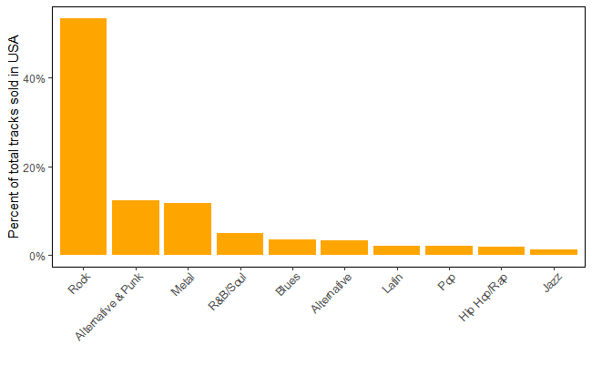

```r
library(ggplot2)
# Note that I use the "top_10_sales" variable generated as the output of the SQL chunk above. Without the SQL chunk, the result of run_query(to_purchase) needs to be assigned to a variable so it can be used in R.

top_genres_plot <- ggplot(data = top_10_sales, aes(x = reorder(genre, -percentage_tracks_sold), y = percentage_tracks_sold)) +
  geom_bar(stat = "identity", fill = "orange") +
  xlab("") +
  ylab("Percent of total tracks sold in USA") +
  scale_y_continuous(labels=scales::percent) +
  theme(axis.text.x = element_text(angle = 45, vjust = 1, hjust = 1))


top_genres_plot
```

## Conclusion

It seems that Rock, Alternative & Punk, and Metal are the 3 top-selling music genres in the USA, so we should include the Punk album by Red Tone. However, we don’t have any new Rock or Metal albums available, so we should choose the next best genres: Blues and Pop.

In sum, the following three albums will be recommended: * Red Tone (Punk) * Slim Jim Bites (Blues) * Meteor and the Girls (Pop).

It would be worth asking the record label if they have any new Rock albums, because this genre is overwhelmingly the bestseller.

# Assessment of sales support rep performance

## 1. Gather all potentially relevant data

```sql
WITH sales_per_rep AS
(
SELECT
i.customer_id,
c.support_rep_id,
SUM(i.total) AS total_sales
FROM invoice AS i
INNER JOIN customer AS c ON c.customer_id = i.customer_id
GROUP BY 1, 2
)
SELECT
e.first_name || " " || e.last_name AS employee,
e.reports_to AS supervisor,
e.hire_date AS hire_date,
e.birthdate AS birthdate,
e.country AS country,
SUM(spr.total_sales) as total_sold
FROM sales_per_rep AS spr
INNER JOIN employee AS e ON e.employee_id = spr.support_rep_id
GROUP BY employee;
```

## 2. Plot the data

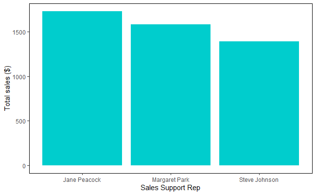

```r
e_perf_plot <- ggplot(data = employee_perf, aes(x = reorder(employee, -total_sold), y = total_sold)) +
  geom_bar(stat = "identity", fill = "cyan3") +
  xlab("Sales Support Rep") +
  ylab("Total sales ($)")

e_perf_plot
```

Jane Peacock has the highest sales amount among the Sales Support Reps. Most of the available employee characteristics are the same between each of the reps, except for date of hire and birth date. It’s unlikely that age has a big impact on their sales, but more experienced employees may sell more due to various factors like increased skill or rapport with clients. Let’s visualize how long each employee has been with the company:

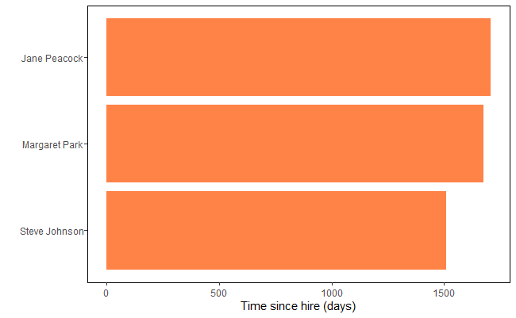

```r
library(lubridate)
library(tidyverse)

hire_timeline <- employee_perf %>%
  select(employee, hire_date, birthdate) %>%
  mutate(hire_date = lubridate::as_date(hire_date),
         time_since_hire = lubridate::today() - hire_date,
         birthdate = lubridate::as_date(birthdate),
         age = (lubridate::today() - birthdate)/365)


plot_time <- ggplot(data = hire_timeline, aes(x = reorder(employee, time_since_hire), y = time_since_hire)) +
  geom_bar(stat = "identity", fill = "sienna1") +
  coord_flip() +
  xlab("") +
  ylab("Time since hire (days)") +
  theme(axis.text.y = element_text(angle = 0))
plot_time
```

Let’s also look at their respective ages, keeping in mind that we don’t know enough about these employees to know what other factors influencing their performance might be correlated with age. This means that even if we find big differences in age, we can’t draw any firm conclusions about their relationship to employee sales.

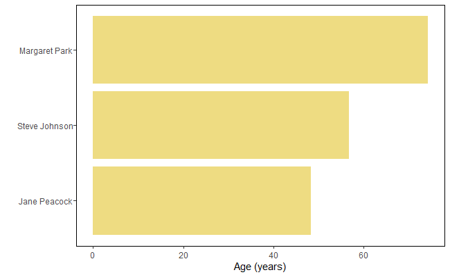

```r
age_plot <- ggplot(data = hire_timeline, aes(x = reorder(employee, age), y = age)) +
  geom_bar(stat = "identity", fill = "lightgoldenrod2") +
  coord_flip() +
  xlab("") +
  ylab("Age (years)") +
  theme(axis.text.y = element_text(angle = 0))
age_plot
```

## Conclusion:

Jane Peacock has been with the company the longest, but not by much longer than Margaret Park, so it seems unlikely that this has had a significant effect on her performance, unless she had relevant experience in sales before she joined the company. She is also the youngest, but Margaret Park is the oldest, yet has the second-highest total dollar amount of sales, so it’s also unlikely that age can explain the observed differences in performance. A more detailed view of these employees’ work patterns, like working hours and total number of days worked, and/or their professional background, is needed to better explain this variability.

# Sales for each different country (ignoring country data from invoice table)

## 1. Gather the data

```sql
WITH dummy_code AS
(
SELECT
     CASE WHEN (
                SELECT COUNT(*)
                FROM customer AS c
                WHERE country = c.country
                ) = 1 THEN "Other"
          ELSE c.country
    END AS country,
    c.customer_id,
    il.*
FROM invoice_line AS il
INNER JOIN invoice aS i ON i.invoice_id = il.invoice_id
INNER JOIN customer AS c ON c.customer_id = i.customer_id
)

SELECT
country,
customers,
total_sales,
average_sales_per_c,
average_order_val
FROM
(
    SELECT
    country,
    COUNT(DISTINCT customer_id) AS customers,
    SUM(unit_price) AS total_sales,
    SUM(unit_price)/COUNT(DISTINCT customer_id) AS average_sales_per_c,
    SUM(unit_price)/COUNT(DISTINCT invoice_id) AS average_order_val,
    CASE
      WHEN country = "Other" THEN 1
      ELSE 0
    END AS sorting
    FROM dummy_code
    GROUP BY country
    ORDER BY sorting ASC, total_sales DESC
);
```

```r
# temporary stopgap to correct "Other" labeling as even solution provided by Dataquest did not work

sales_bycountry <- sales_bycountry %>%
  mutate(country = if_else(customers == 1, "Other", country))
```

## 2. Plots

Number of customers by country (excluding “Other” countries which had only 1 customer):

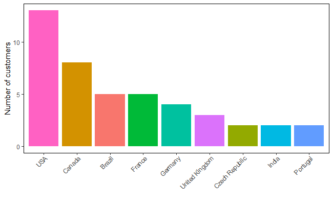

```r
sales_bycountry_cut <-  sales_bycountry %>% filter(country != "Other")

cust <- ggplot(data = sales_bycountry_cut, aes(x = reorder(country, -customers), y = customers, fill = country)) +
  geom_bar(stat = "identity") +
  xlab("") +
  ylab("Number of customers") +
  theme(axis.text.x = element_text(angle = 45, hjust = 1, vjust = 1),
        legend.position = "none")

cust
```

Total sales by country (again excluding “Other”):

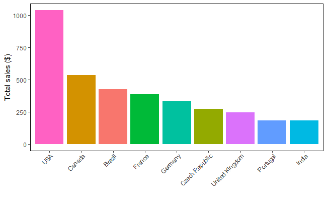

```r
tot_sold <- ggplot(data = sales_bycountry_cut, aes(x = reorder(country, -total_sales), y = total_sales, fill = country)) +
  geom_bar(stat = "identity") +
  xlab("") +
  ylab("Total sales ($)") +
  theme(axis.text.x = element_text(angle = 45, hjust = 1, vjust = 1),
        legend.position = "none")

tot_sold
```

Average sales per customer:

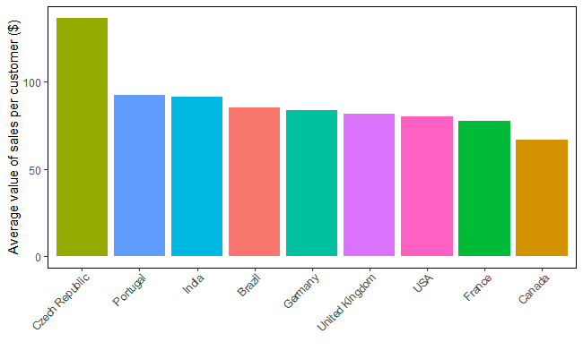

```r
sales_per_c <- ggplot(data = sales_bycountry_cut, aes(x = reorder(country, -average_sales_per_c), y = average_sales_per_c, fill = country)) +
  geom_bar(stat = "identity") +
  xlab("") +
  ylab("Average value of sales per customer ($)") +
  theme(axis.text.x = element_text(angle = 45, hjust = 1, vjust = 1),
        legend.position = "none")

sales_per_c
```

Average order value by country:

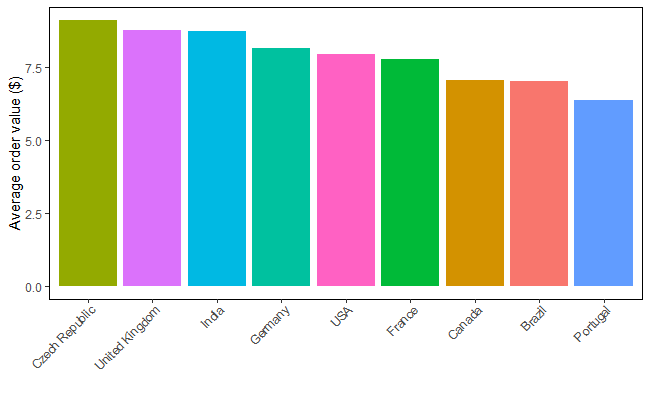

```r
order_val <- ggplot(data = sales_bycountry_cut, aes(x = reorder(country, -average_order_val), y = average_order_val, fill = country)) +
  geom_bar(stat = "identity") +
  xlab("") +
  ylab("Average order value ($)") +
  theme(axis.text.x = element_text(angle = 45, hjust = 1, vjust = 1),
        legend.position = "none")

order_val
```

# Conclusion

The USA is the biggest market, largely because it has the most customers, as these customers are not the biggest spenders. The data shows that the biggest spenders are in the Czech Republic, where both the average value of sales per customer and the average order value are highest despite it having one of the smallest numbers of customers (though note that the average order value varies relatively little between countries so it might not be the most meaningful metric).

Based on this data, the Czech Republic seems like a market with potential for growth. Perhaps other countries with few customers but relatively high average sales values per customer and/or order vales, as well as large populations with access to the internet (e.g., Portugal, India, United Kingdom) might also be candidates for potential growth, but generally it would be helpful to have more detailed data on customers and their behaviour (e.g., historical changes, demographics) in order to be able to make better recommendations.

# Should the store continue to buy full albums from record labels?

## 1. Find out how many sales were for full albums versus individual tracks

```sql
--This was a particularly difficult part of the exercise and caused much confusion on the discussion forums as well, so I break down the purpose of each step here using comments

--First, get the first track of each invoice and define new table invoice_first_track (ifs)
WITH invoice_first_track AS
    (
     SELECT
         il.invoice_id invoice_id,
         MIN(il.track_id) first_track_id
     FROM invoice_line il
     GROUP BY 1
    )
SELECT --then select final columns (including is_album which hasn't been defined yet)
    is_album,
    COUNT(invoice_id) AS n_invoices,
    CAST(COUNT(invoice_id) AS FLOAT) / (SELECT COUNT(*) FROM invoice) AS percent
FROM --then define the subset of invoice_first_track to select from
    (
    SELECT
        ifs.*, --i.e., all values of ifs where
        CASE
            WHEN
                 (--the difference between the list of tracks corresponding to each invoice in ifs
                  SELECT il2.track_id FROM invoice_line il2
                  WHERE il2.invoice_id = ifs.invoice_id

                  EXCEPT -- and the list of tracks belonging to albums to which tracks in invoice_first_track belong

                  SELECT t.track_id FROM track t
                  WHERE t.album_id = (
                                      SELECT t2.album_id FROM track t2
                                      WHERE t2.track_id = ifs.first_track_id
                                     )
                 ) IS NULL -- is null
             AND
                 (-- the difference between the list of tracks corresponding to each invoice in ifs
                  SELECT il2.track_id FROM invoice_line il2
                  WHERE il2.invoice_id = ifs.invoice_id
                  EXCEPT -- and the list of tracks belonging to the albums to which the tracks in ifs belong
                  SELECT t.track_id FROM track t
                  WHERE t.album_id = (
                                      SELECT t2.album_id FROM track t2
                                      WHERE t2.track_id = ifs.first_track_id
                                     )
                 ) IS NULL -- is null
             THEN "1" -- fill the new column of ifs is_album with 1 if the above differences are NULL (i.e., the purchases are for whole albums), and 0 if they are not (i.e., the purchases are for individual tracks)
             ELSE "0"
         END AS "is_album"
     FROM invoice_first_track ifs
    )
GROUP BY is_album;
```

## 2. Visualization

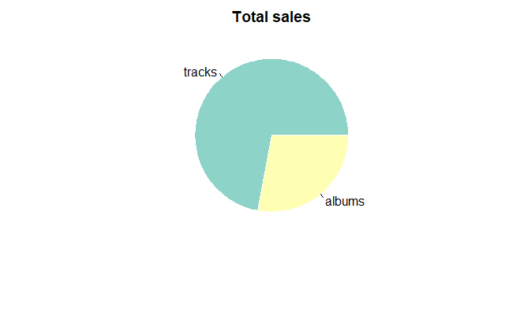

```r
library(RColorBrewer)
colour <- brewer.pal(3, "Set3")

pie(albums_vs_ind$percent, labels = c("tracks", "albums"), border = "white", col = colour, main = "Total sales")
```

```r
# Note: while pie and donut charts are generally a bad idea for data viz because it can be difficult to grasp the relative magnitude of each "slice", in this particular case it's alright because there are only two categories of sales to represent (tracks and albums) and it makes a nice change from bar charts.
```

# “Bonus” questions:

1. which artist is used the most in playlists?
2. How many tracks have been purchased vs not purchased?
3. Does the range of tracks in the store reflect their sales popularity?
4. Do protected vs non-protected media types have an effect on popularity?

## 1. Which artist features most often in playlists?

There are two ways we could define “most used” here - artists with the most tracks contained in playlists, and artists who have at least 1 track in the most playlists. Data for both definitions is gathered here:

```sql
WITH playlist_info AS (
SELECT p.*, pt.*, t.*, g.*
FROM playlist AS p
INNER JOIN playlist_track AS pt ON pt.playlist_id = p.playlist_id
INNER JOIN track AS t ON t.track_id = pt.track_id
INNER JOIN genre AS g On g.genre_id = t.genre_id
),
  artist_info AS (
  SELECT ar.*, al.*
  FROM album AS al
  INNER JOIN artist AS ar ON ar.artist_id = al.artist_id
  ),

  playlists_with_artists AS (
  SELECT
  pi.playlist_id AS playlist_id,
  ai.artist_id AS artist_id,
  ai.name AS artist_name,
  COUNT(pi.track_id) AS n_tracks
  FROM playlist_info AS pi
  INNER JOIN artist_info AS ai ON ai.album_id = pi.album_id
  GROUP BY playlist_id, artist_name
  )

SELECT
artist_name,
artist_id,
COUNT(playlist_id) AS n_playlists,
n_tracks
FROM playlists_with_artists AS pwa
GROUP BY artist_name
ORDER BY n_tracks DESC;
```

```r
head(artist_pop)
```

|  | artist_name | artist_id | n_playlists | n_tracks |
| --- | --- | --- | --- | --- |
| 1 | Iron Maiden | 90 | 4 | 213 |
| 2 | U2 | 150 | 3 | 135 |
| 3 | Led Zeppelin | 22 | 3 | 114 |
| 4 | Metallica | 50 | 4 | 112 |
| 5 | Lost | 149 | 2 | 92 |
| 6 | Deep Purple | 58 | 3 | 92 |

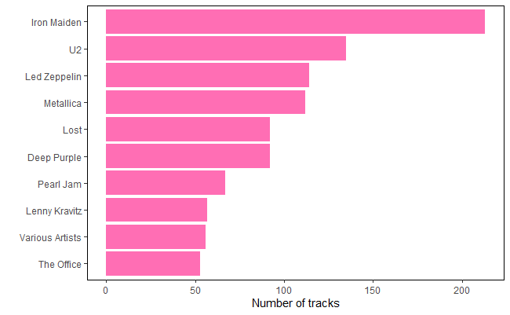

```r
artist_top10_tracks <- artist_pop %>% slice_max(order_by = n_tracks, with_ties = TRUE, n = 10)

tracks <- ggplot(data = artist_top10_tracks, aes(x = reorder(artist_name, n_tracks), y = n_tracks)) +
  geom_bar(stat = "identity", fill = "hotpink1") +
  coord_flip() +
  xlab("") +
  ylab("Number of tracks")


tracks
```

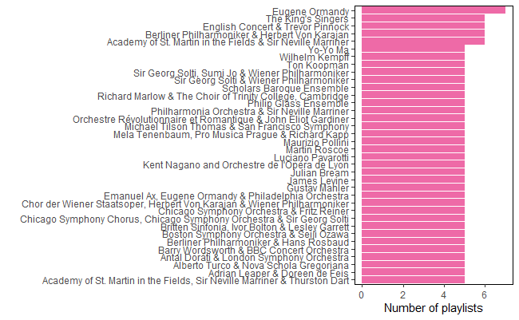

```r
artist_top10_play <- artist_pop %>% slice_max(order_by = n_playlists, with_ties = TRUE, n = 10)

play <- ggplot(data = artist_top10_play, aes(x = reorder(artist_name, n_playlists), y = n_playlists)) +
  geom_bar(stat = "identity", fill = "hotpink2") +
  coord_flip() +
  xlab("") +
  ylab("Number of playlists")


play
```

Note that the list of “Top 10” artists in terms of the number of playlists they feature in is much longer than just 10. This is because I chose to allow ties when slicing the data - you can see on the graph that most of the artists feature in exactly the same number of playlists. Using `n_tracks` as a secondary ordering variable would not have been useful as there are also lots of ties there.

## Conclusion:

Most of the top 10 artists in terms of number of tracks featured in playlists are Rock and Metal artists, while most of those whose popularity is defined as the number of playlists they feature in make classical music. The most popular artist is therefore either Iron Maiden or Eugene Ormandy. Caveat: there are a few artist names which actually contain several different artists, so this data would have to be processed a bit more to reflect the true number of tracks and playlists per individual artist. This is not the point of this exercise though, and each artist name, whether it contains one or more actual artists, is associated with a single artist ID, which suggests that the store is more interested in the performance of each artist as identified by the ID, so I’m not going to do that processing here.

## 2. How many tracks have been purchased vs not purchased?

```sql
WITH purchased_tracks AS (
    SELECT
        i.invoice_id AS invoice_id,
        il.track_id AS track_id
    FROM invoice AS i
    INNER JOIN invoice_line AS il
    )

SELECT
   COUNT(DISTINCT t.track_id) AS n_tracks_total,
   COUNT(DISTINCT pt.track_id) AS n_tracks_purchased,
   CAST(COUNT(DISTINCT pt.track_id) AS FLOAT)/(COUNT(DISTINCT t.track_id)) AS prop_purchased
FROM track AS t
LEFT JOIN purchased_tracks AS pt ON pt.track_id = t.track_id;
```

```r
tracks_purchased
```

| n_tracks_total | n_tracks_purchased | prop_purchased |
| --- | --- | --- |
| 3503 | 1806 | 0.5155581 |

```r
NA
```

1806 of the 3503 available tracks were purchased, or about 50%. This seems a bit low, which may indicate that the range of tracks the store has available doesn’t reflect their relative popularity as well as it could. This leads us to the next question:

## 3. Does the range of tracks in the store reflect their sales popularity?

```sql
WITH track_range AS (
    SELECT
        g.*,
        t.track_id AS track_id,
        t.genre_id AS genre_id
    FROM genre AS g
    INNER JOIN track AS t ON g.genre_id = t.genre_id
    ),
    sold_range AS (
    SELECT
        t.genre_id AS genre_id,
        il.track_id AS track_id,
        i.invoice_id As invoice_id
    FROM invoice_line AS il
    INNER JOIN track AS t ON t.track_id = il.track_id
    INNER JOIN invoice AS i ON i.invoice_id = il.invoice_id
    )

SELECT
    tr.name,
    COUNT(DISTINCT tr.track_id) AS n_tracks,
    COUNT(DISTINCT sr.track_id) AS n_sold,
    RANK () OVER (
        ORDER BY COUNT(DISTINCT tr.track_id) DESC
        ) AS tot_rank,
        RANK () OVER (
        ORDER BY COUNT(DISTINCT sr.track_id) DESC
        ) AS sold_rank,
        CAST(COUNT(DISTINCT sr.track_id) AS FLOAT)/COUNT(DISTINCT tr.track_id) AS prop_sold
FROM track_range AS tr
LEFT JOIN sold_range AS sr ON sr.genre_id = tr.genre_id
GROUP BY 1
ORDER BY sold_rank;
```

```r
track_pop_range_long <- track_pop_range %>% select(c(1:3)) %>% pivot_longer(cols = c(n_tracks, n_sold), names_to = "type", values_to = "n")

track_pop_range
```

| name | n_tracks | n_sold | tot_rank | sold_rank | prop_sold |
| --- | --- | --- | --- | --- | --- |
| Rock | 1297 | 915 | 1 | 1 | 0.70547417 |
| Metal | 374 | 238 | 3 | 2 | 0.63636364 |
| Alternative & Punk | 332 | 176 | 4 | 3 | 0.53012048 |
| Latin | 579 | 119 | 2 | 4 | 0.20552677 |
| Jazz | 130 | 61 | 5 | 5 | 0.46923077 |
| Blues | 81 | 56 | 7 | 6 | 0.69135802 |
| R&B/Soul | 61 | 55 | 10 | 7 | 0.90163934 |
| Alternative | 40 | 34 | 14 | 8 | 0.85000000 |
| Electronica/Dance | 30 | 29 | 16 | 9 | 0.96666667 |
| Pop | 48 | 25 | 12 | 10 | 0.52083333 |

[output cut: 15 more lines]

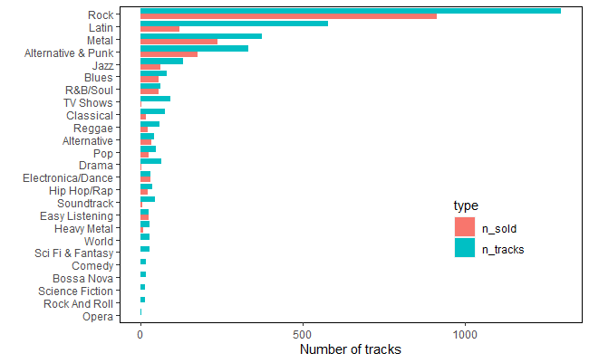

```r
pop_range <- ggplot(data = track_pop_range_long, aes(x = reorder(name, n), y = n, fill = type)) +
  geom_bar(stat = "identity", position = "dodge") +
  coord_flip() +
  xlab("") +
  ylab("Number of tracks") +
  theme(legend.position = c(0.8, 0.3))

pop_range
```

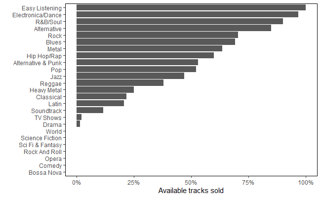

```r
pop_range <- ggplot(data = track_pop_range, aes(x = reorder(name, prop_sold), y = prop_sold)) +
  geom_bar(stat = "identity") +
  coord_flip() +
  xlab("") +
  ylab("Available tracks sold") +
  scale_y_continuous(labels = scales::percent) +
  theme(legend.position = "none")

pop_range
```

## Conclusion:

We can see from the first plot that, in terms of the number of tracks available in the store, the range looks mostly representative of each genre’s popularity (defined as the number of sales), with a few exceptions. For example, there are many more Latin tracks than are actually sold.

Another way to represent how well the number of tracks matches each genre’s popularity could be to consider the proportion of tracks sold for each genre. Selections with a higher proportion of tracks sold are more likely to be representative of their genre’s popularity since they don’t have too many extra (unsold) tracks, while those with lower proportions of tracks sold are less so. However, having a very high percentage of tracks sold can also indicate that there are very few tracks available, or that there may be a higher demand for the genre in question (there aren’t enough extra tracks).

We can compare the number of tracks available to the number of tracks sold to see if it’s the first possibility, but other data like historical data on customers’ purchasing patterns for each genre would be needed to look into the second possibility. It would also be useful to survey customers, e.g., to find out whether they wish there were more tracks for certain genres.